# User_analysis

qingye

# 本报告对双十一活动，2017-11-11至2017-11-12 两天用户的行为进行了分析

#### 包括反映用户数目的UV,反映用户活跃度的：人均PV,用户活跃时长,以及反映用户黏度的次日留存，本次报告加入了路径深度的分析,加入了转化部分,并采用多种方式作图

#### 本次报告用R语言自动化生成报告的框架搭建，今后将在此基础上不断改进优化，下次报告将深化转化方面的分析(加入渠道分析)，加深对于路径方面的分析，引进智能化的异常值提醒和分析，考虑加入排名变动

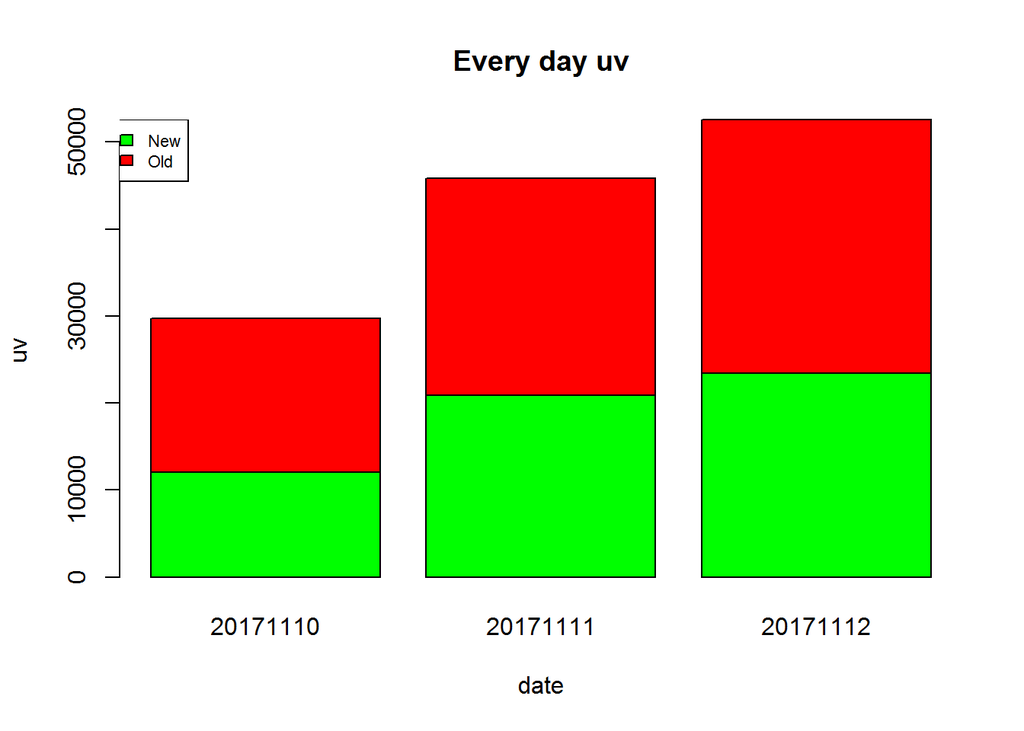

平均UV为42714,

最大UV为52573,

最大值发生在20171112

有0 天新用户在UV值上超过老用户

并没有哪天 用户UV明显高于平均值 20171110 用户UV明显低于平均值

## 双十一人均PV

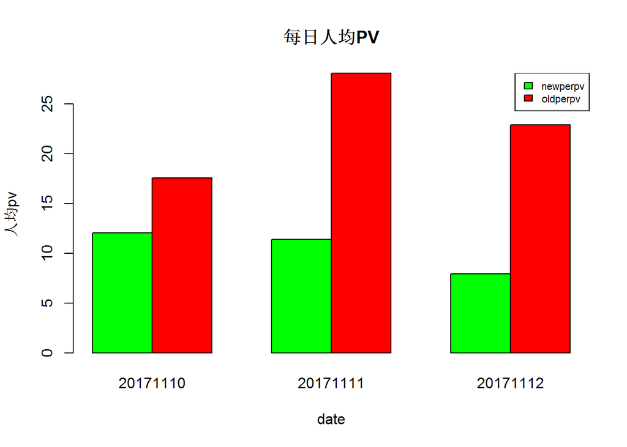

总体人均PV均值为17.3265903

总体人均PV最大值为20.4729529 最大值发生在 20171111

总体人均PV最小值为15.2916695 最小值发生在 20171110

新用户人均PV均值为10.4433161

新用户人均PV最大值为12.0174028 最大值发生在 20171110

新用户人均PV最小值为7.9348252 最小值发生在 20171112

老用户人均PV均值为22.828281

老用户人均PV最大值为28.0676033 最大值发生在 20171111

老用户人均PV最小值为17.529595 最小值发生在 20171110

有0 天新用户在人均PV值上超过老用户

20171111 新用户和老用户的趋势不一样

## PV 趋势图，篮框内为聚焦时期

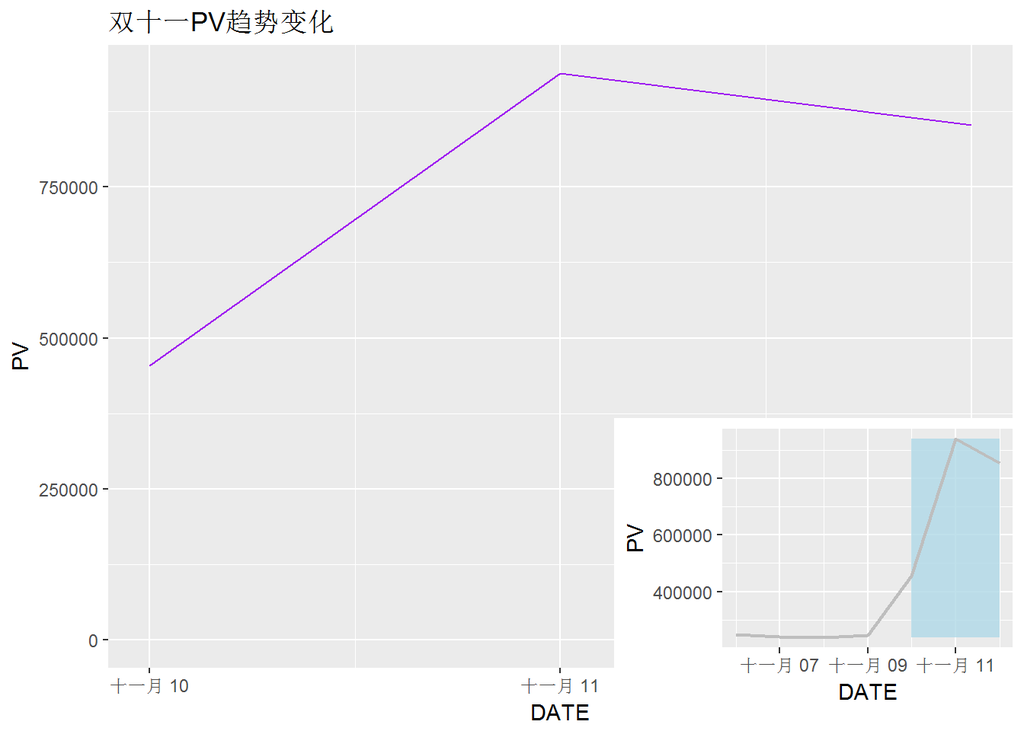

画中画分析，大图，小图高亮的那部分，表示示双十一pv趋势，而小图表示近一周的pv情况 双十一比过去近一周整体pv要高

## 用户活跃时长

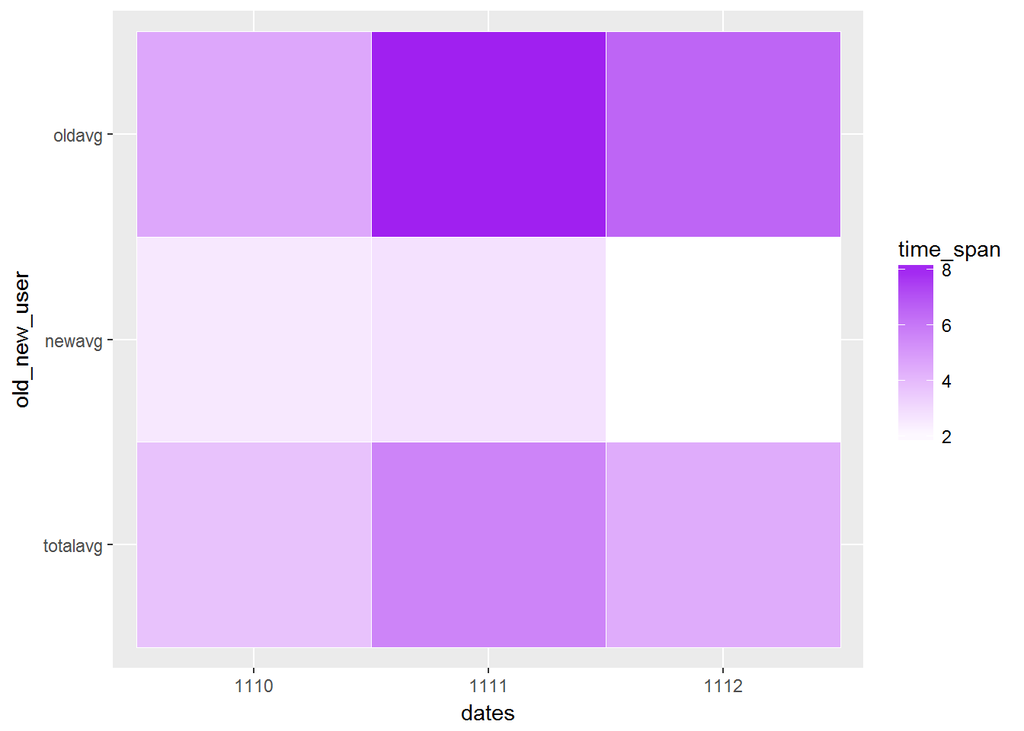

对于用户访问时长作的热力图，可以看出新老用户差距明显，新用户大部分日子访问时长接近白色 双十一当天的用户访问时长明显高过11月10日以及11月12日，无论新用户还是老用户

## 次日留存

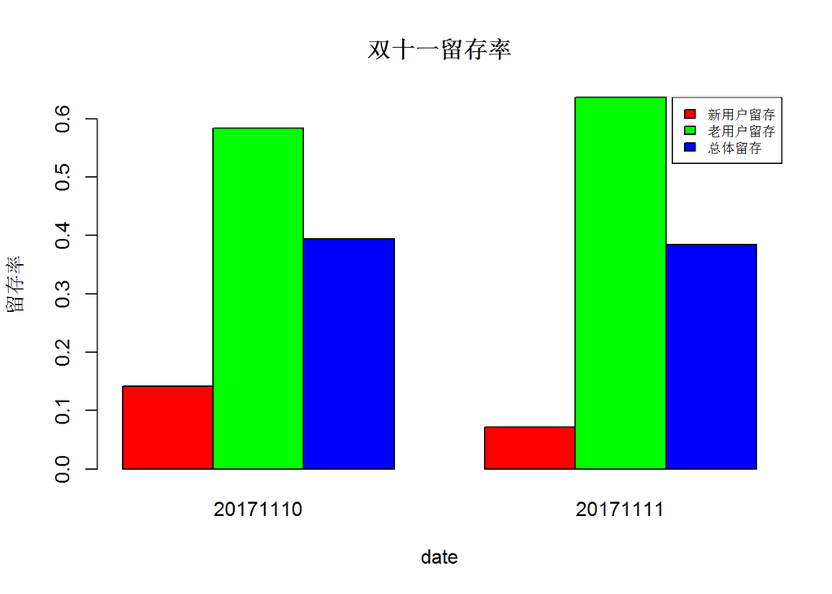

## 新老用户访问平均深度（按人头）

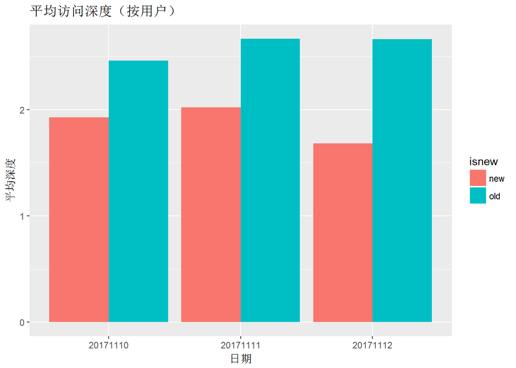

## 新用户不同机型分布

|  | sym | model | 2017-11-11 | 2017-11-12 | sum | rank |
| --- | --- | --- | --- | --- | --- | --- |
| 1 | 0 | iPhone 5c | 476 | 4505 | 4981 | 1 |
| 2 | 0 | iPhone 5s | 481 | 2864 | 3345 | 2 |
| 3 | 1▲ | iPhone 5 | 373 | 2693 | 3066 | 3 |
| 4 | -1▼ | iPhone 6 | 835 | 1673 | 2508 | 4 |
| 5 | 0 | iPhone 6 Plus | 683 | 1737 | 2420 | 5 |
| 6 | 1▲ | iPhone 4S | 162 | 1333 | 1495 | 6 |
| 7 | 2▲ | iPhone 7 Plus | 527 | 356 | 883 | 7 |
| 8 | 0 | iPhone 6s | 501 | 322 | 823 | 8 |
| 9 | 1▲ | iPhone 6s Plus | 459 | 275 | 734 | 9 |
| 10 | 2▲ | iPhone 7 | 393 | 265 | 658 | 10 |

[output cut: 90 more lines]

## 新用户不同城市分布

|  | sym | city | 2017-11-11 | 2017-11-12 | sum | rank |
| --- | --- | --- | --- | --- | --- | --- |
| 57 | 0 | 泉州 | 6197 | 4857 | 11054 | 1 |
| 67 | 1▲ | 苏州 | 5376 | 3056 | 8432 | 2 |
| 60 | -1▼ | 上海 | 2519 | 2148 | 4667 | 3 |
| 63 | 0 | 沈阳 | 255 | 3752 | 4007 | 4 |
| 6 | 1▲ | 北京 | 1786 | 1231 | 3017 | 5 |
| 56 | -1▼ | 清远 | 173 | 2339 | 2512 | 6 |
| 50 | 0 | 南京 | 1461 | 742 | 2203 | 7 |
| 26 | 0 | 合肥 | 603 | 336 | 939 | 8 |
| 46 | 32▲ | 漯河 | 279 | 396 | 675 | 9 |
| 89 | -1▼ | 扬州 | 276 | 284 | 560 | 10 |

[output cut: 91 more lines]

## 新用户不同渠道分布

|  | channels | 2017-11-11 | 2017-11-12 | sum |
| --- | --- | --- | --- | --- |
| 1 | 二维码-Android | 11405 | 8030 | 19435 |
| 2 | Appstore | 1321 | 5574 | 6895 |
| 3 | 二维码-IOS | 2589 | 4300 | 6889 |
| 4 | 30015 | 3172 | 3127 | 6299 |
| 5 | 360手助 | 522 | 682 | 1204 |
| 6 | vivo | 502 | 528 | 1030 |
| 7 | 华为 | 359 | 335 | 694 |
| 8 | 小米 | 182 | 219 | 401 |
| 9 | 二维码-其他 | 269 | 93 | 362 |
| 10 | 百度手助 | 166 | 155 | 321 |

[output cut: 19 more lines]

# 转化问题

## 每日订单数

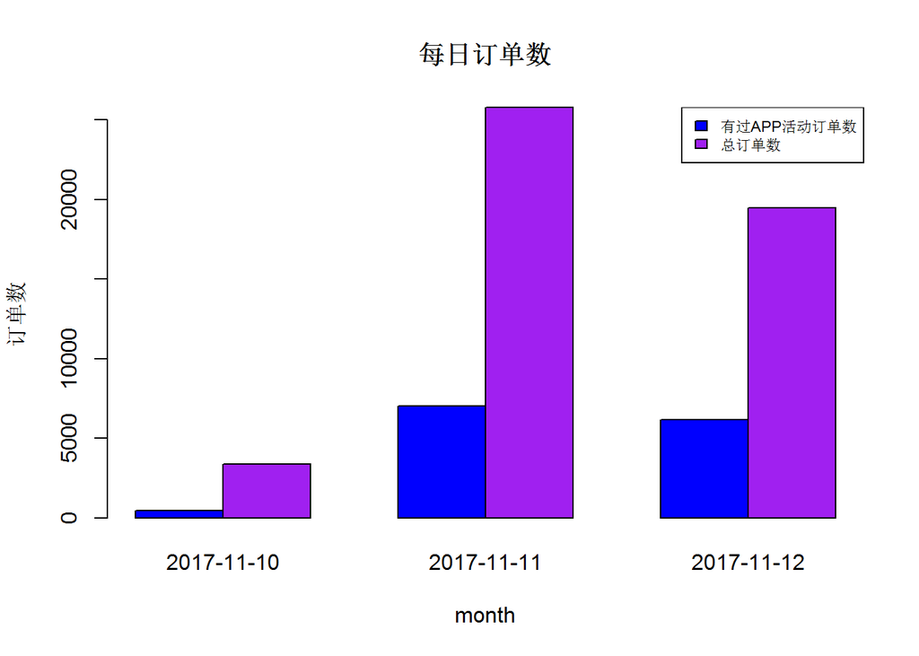

## 家装预约

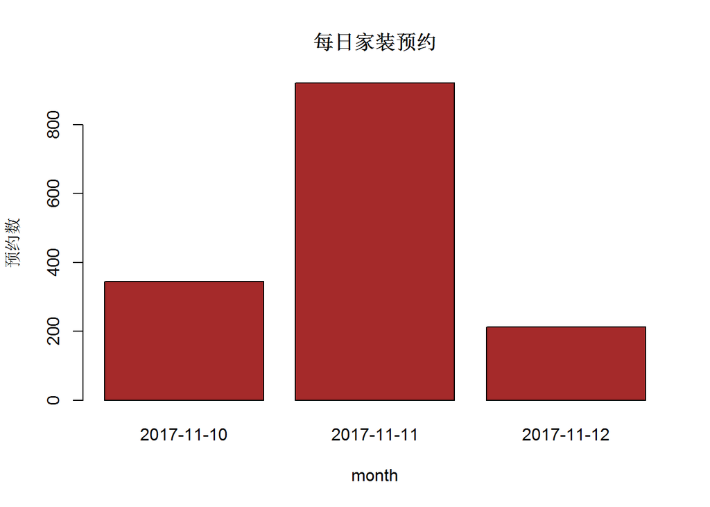

## 领券情况

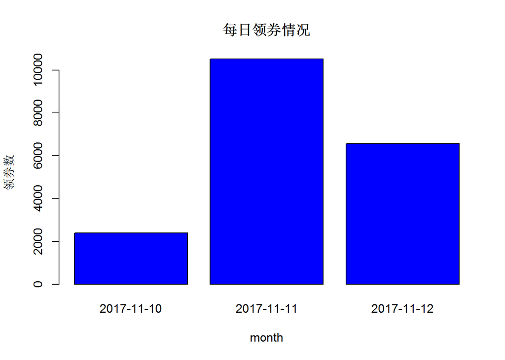